# R Notebook

## Load data

Load datasets and mark DLI patients. Check number of clonotypes in donors and receptients - we have engough clones for statistics everywhere. We group clones by their abundance in donors: 1 (singletons), 2 (doubletons), 3 (tripletons, as good as doubletons, no need to hate them Vanya) and 4+ reads (Large). The choice is dictated by observing the fact that for rare events Poisson distribution shows huge difference in capture probability for $\lambda \in [1,3]$ while smaller $\lambda$ values are unlikely to be encountered and quantified. Moreover, for large clones, each hyperexpanded variant has its own history and, likely, its own dynamic, so binning them to different bins based on minor differences in frequency (e.g. $0.1\%$ vs $0.01\%$) makes little sense.

[output not shown]

[output cut: 9 more lines]

[output not shown]

```r
data %>%
  select(sample.id.old, dli, sample.id) %>%
  unique

data
```

| nSeqCDR3 | bestVGene | cloneCount.rec | aaSeqCDR3.rec | cloneCount.don | aaSeqCDR3.don | sample.id | sample.id.old | dli |
| --- | --- | --- | --- | --- | --- | --- | --- | --- |
| AAAAGGACGGGTTTAGGACTAATGAAAAACTGTTTTTT | TRBV25-1 | 1 | KRTGLG_NEKLFF | NA | NA | D1* | tcr-survival-model/data/sh.Art.txt.gz | TRUE |
| AAAATAAGGGTCCCAGGACACTGAAGCTTTCTTT | TRBV20-1 | 1 | KIRVPG_TEAFF | NA | NA | D1* | tcr-survival-model/data/sh.Art.txt.gz | TRUE |
| AACAGCGTCCTCGAGGGGGAAAACATTCAGTACTTC | TRBV29-1 | NA | NA | 1 | NSVLEGENIQYF | D1* | tcr-survival-model/data/sh.Art.txt.gz | TRUE |
| AACAGTGCTAGAGATTCAGGCGGGAGCTCCTACGAGCAGTACTTC | TRBV20-1 | NA | NA | 1 | NSARDSGGSSYEQYF | D1* | tcr-survival-model/data/sh.Art.txt.gz | TRUE |
| AACCCCCCCTCAGAAGGGAAGCCCTGGAGAAAAACTGTTTTTT | TRBV5-1 | NA | NA | 1 | NPPSEGK_PGEKLFF | D1* | tcr-survival-model/data/sh.Art.txt.gz | TRUE |
| AAGGGGGACAGATCTACAATGAGCAGTTCTTC | TRBV19 | 1 | KGDRS_NEQFF | NA | NA | D1* | tcr-survival-model/data/sh.Art.txt.gz | TRUE |
| ACCAGCAGCCCAGGTGGGACTGGGATACTTTACGAGCAGTACTTC | TRBV5-1 | 1 | TSSPGGTGILYEQYF | NA | NA | D1* | tcr-survival-model/data/sh.Art.txt.gz | TRUE |
| ACCAGCAGCTTGGGGAAAGTAGGCTACGAGCAGTACTTC | TRBV5-1 | 1 | TSSLGKVGYEQYF | NA | NA | D1* | tcr-survival-model/data/sh.Art.txt.gz | TRUE |
| ACCAGCAGTACAGGGGGCGACCCCAAAAACATTCAGTACTTC | TRBV5-1 | 1 | TSSTGGDPKNIQYF | NA | NA | D1* | tcr-survival-model/data/sh.Art.txt.gz | TRUE |
| ACCGGGGGGCCCTACGAGCAGTACTTC | TRBV6-1 | 2 | TGGPYEQYF | NA | NA | D1* | tcr-survival-model/data/sh.Art.txt.gz | TRUE |

[output cut: 990 more lines]

[output not shown]

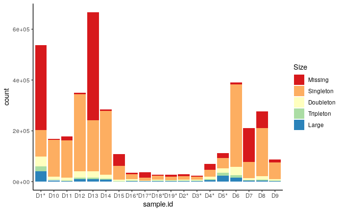

```r
data <- data %>%
  mutate(donor.quantile = case_when(
    is.na(cloneCount.don) ~ "Missing",
    cloneCount.don == 1 ~ "Singleton",
    cloneCount.don == 2 ~ "Doubleton",
    cloneCount.don == 3 ~ "Tripleton",
    T ~ "Large"
    ))

data %>%
  mutate(cloneCount.don = ifelse(is.na(cloneCount.don), 0, cloneCount.don)) %>%
  ggplot(aes(x = sample.id,
             fill = donor.quantile %>%
               fct_reorder(cloneCount.don))) +
  geom_bar() +
  scale_fill_brewer("Size", palette = "Spectral") +
  theme_classic()
```

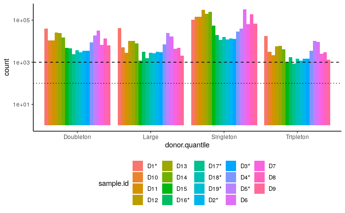

```r
data %>%
  filter(donor.quantile != "Missing") %>%
  ggplot(aes(x = donor.quantile,
             fill = sample.id)) +
  geom_bar(position = "dodge") +
  scale_y_log10() +
  geom_hline(yintercept = 100, linetype = "dotted") +
  geom_hline(yintercept = 1000, linetype = "dashed") +
  theme_classic() +
  theme(legend.position = "bottom")
```

## Add probability from OLGA. Be careful. You should remove NA-value and duplicated value from OLGA table.

```r
don_table <-read_tsv('don_pgens_norm.tsv', col_names = c('aaSeqCDR3.don', 'pgens.don'))
```

```
1 parsing failure.
    row col  expected    actual                 file
2062906  -- 2 columns 4 columns 'don_pgens_norm.tsv'
```

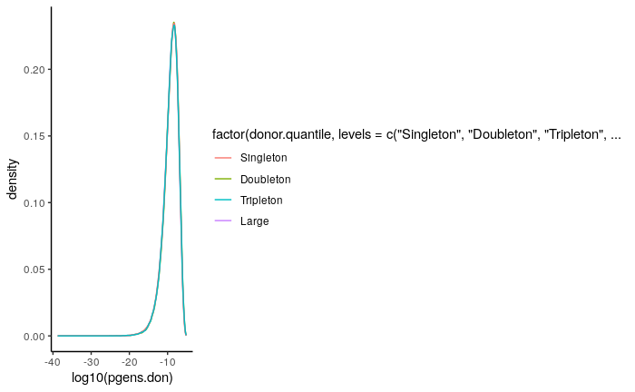

```r
don_table <- don_table %>% filter(aaSeqCDR3.don != 'NA')
don_table <- unique(don_table)

# add probability
data <- left_join(data, don_table)
data.don  <- data%>% filter(pgens.don != 'NA')

# we count only for donors, because we will filter missing clonotypes
med <- median(data.don$pgens.don)

# split data on high_possible, low_possible, unpossible
data <- data %>% mutate(probability.CDR3 = case_when(pgens.don < med ~ 'high_possible',
                        pgens.don >= med ~ 'low_possible',
                        T ~ 'unpossible'))


data%>% ggplot(aes(x=log10(pgens.don), group=donor.quantile, color = factor(donor.quantile, levels =                                                                c("Singleton",
                                                      "Doubleton",
                                                      "Tripleton",
                                                      "Large")))) +
    geom_line(stat="density") +  theme_classic()
```

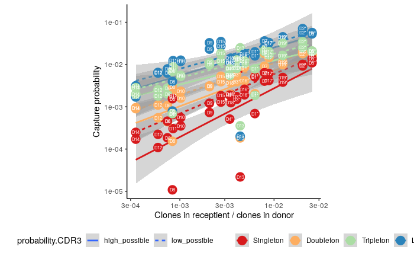

```r
alpha.prior <- 1
beta.prior <- 1
data.s <- data %>%
  filter(donor.quantile != "Missing") %>%
  group_by(sample.id) %>%
  mutate(total.don = sum(cloneCount.don, na.rm = T),
         clones.don = length(unique(aaSeqCDR3.don)), # note here we count +1 for NA, maybe should modify it
         total.rec = sum(cloneCount.rec, na.rm = T),
         clones.rec = length(unique(aaSeqCDR3.rec))) %>%
  group_by(sample.id, donor.quantile) %>%
  mutate(clones.don.quant = length(unique(aaSeqCDR3.don))) %>%
  group_by(dli, sample.id, donor.quantile, total.don, clones.don, total.rec, clones.rec, clones.don.quant, probability.CDR3) %>%
  summarize(alpha = sum(!is.na(cloneCount.rec)) + alpha.prior,
            beta = sum(is.na(cloneCount.rec)) + beta.prior) %>%
  ungroup
data.s %>% filter(probability.CDR3 != 'unpossible') %>%
  ggplot(aes(x = clones.rec / clones.don, y = alpha / (alpha + beta),
             group = paste(donor.quantile, probability.CDR3),
             linetype = probability.CDR3,
             color = factor( donor.quantile, levels = c("Singleton",
                                                      "Doubleton",
                                                      "Tripleton",
                                                      "Large")))) +
  geom_smooth(method = "lm", aes(), size = 1) +
  geom_point(size = 5) +
  geom_text(aes(label = sample.id), size = 2, color = "white") +
  scale_x_log10("Clones in receptient / clones in donor") +
  scale_y_log10("Capture probability") +
  scale_color_brewer("", palette = "Spectral") +
  theme_classic() +
  theme(aspect = 1, legend.position = "bottom")
```

```r
data.coord <- data.s %>%
  group_by(donor.quantile) %>%
  mutate(logRecaptureProb = log(alpha / (alpha + beta)),
         logClonesRecepient = log(clones.rec),
         logClonesDonor = log(clones.don)) %>%
  ungroup %>%
  mutate(donor.quantile = factor(donor.quantile, levels = c("Singleton",
                                                       "Doubleton",
                                                       "Tripleton",
                                                       "Large")))
data.coord %>%
  ungroup %>% filter(probability.CDR3 != 'unpossible') %>%
  mutate(donor.quantile = as.factor(donor.quantile)) %>%
  do(lm(.$logRecaptureProb ~ .$dli + .$logClonesRecepient + .$logClonesDonor + .$probability.CDR3 + .$donor.quantile) %>% tidy)
```

| term | estimate | std.error | statistic | p.value |
| --- | --- | --- | --- | --- |
| (Intercept) | 1.6834752 | 1.20968414 | 1.391665 | 1.661698e-01 |
| .$dliTRUE | -0.4896603 | 0.22902012 | -2.138067 | 3.419933e-02 |
| .$logClonesRecepient | 0.6711325 | 0.08679736 | 7.732176 | 1.670546e-12 |
| .$logClonesDonor | -1.0792965 | 0.11312526 | -9.540720 | 5.072658e-17 |
| .$probability.CDR3low_possible | 0.5584774 | 0.13806411 | 4.045059 | 8.496111e-05 |
| .$donor.quantileDoubleton | 1.0691682 | 0.19525213 | 5.475834 | 1.887225e-07 |
| .$donor.quantileTripleton | 1.8723092 | 0.19525213 | 9.589187 | 3.809100e-17 |
| .$donor.quantileLarge | 2.4432102 | 0.19525213 | 12.513104 | 8.915177e-25 |

[output not shown]

We split our donor dataset into clonotype in frame and out of frame

[figure not shown]

[output not shown]

[output not shown]

## According to whether the epitope belongs to common viruses or not

```r
virus_table <- read_tsv('/home/volobuevam/tcr-survival-model/vdjdb-dump/vdjdb.slim.txt')
vd <- virus_table %>% select('cdr3', 'antigen.species')
vd1 <- vd %>% mutate(aaSeqCDR3.don = cdr3) %>% select(aaSeqCDR3.don, antigen.species)

data <- left_join(data, vd1)
data <- data %>%
    mutate(prevalence = case_when(
        is.na(antigen.species) ~ 'rare', T~'common'))

data.s3 <- data %>%
  filter(donor.quantile != "Missing") %>%
  group_by(sample.id) %>%
  mutate(total.don = sum(cloneCount.don, na.rm = T),
         clones.don = length(unique(aaSeqCDR3.don)), # note here we count +1 for NA, maybe should modify it
         total.rec = sum(cloneCount.rec, na.rm = T),
         clones.rec = length(unique(aaSeqCDR3.rec))) %>%
  group_by(sample.id, donor.quantile) %>%
  mutate(clones.don.quant = length(unique(aaSeqCDR3.don))) %>%
  group_by(dli, sample.id, donor.quantile, total.don, clones.don, total.rec, clones.rec, clones.don.quant, prevalence)%>%
  summarize(alpha = sum(!is.na(cloneCount.rec)) + alpha.prior,
            beta = sum(is.na(cloneCount.rec)) + beta.prior) %>%
  ungroup
data.coord <- data.s3 %>%
  group_by(donor.quantile) %>%
  mutate(logRecaptureProb = log(alpha / (alpha + beta)),
         logClonesRecepient = log(clones.rec),
         logClonesDonor = log(clones.don)) %>%
  ungroup %>%
  mutate(donor.quantile = factor(donor.quantile, levels = c("Singleton",
                                                       "Doubleton",
                                                       "Tripleton",
                                                       "Large")))

data.coord %>%
  ungroup %>% mutate(donor.quantile = as.factor(donor.quantile)) %>%
  do(lm(.$logRecaptureProb ~ .$dli + .$logClonesRecepient + .$logClonesDonor + .$prevalence + .$donor.quantile) %>% tidy)
```

| term | estimate | std.error | statistic | p.value |
| --- | --- | --- | --- | --- |
| (Intercept) | -2.7797198 | 1.7319528 | -1.604963 | 1.106929e-01 |
| .$dliTRUE | -0.6925907 | 0.3278972 | -2.112219 | 3.639375e-02 |
| .$logClonesRecepient | 0.9601229 | 0.1242712 | 7.726028 | 1.728541e-12 |
| .$logClonesDonor | -0.7013192 | 0.1619659 | -4.330042 | 2.776864e-05 |
| .$prevalencerare | -0.7593473 | 0.1976719 | -3.841454 | 1.827781e-04 |
| .$donor.quantileDoubleton | 1.2033417 | 0.2795502 | 4.304563 | 3.075398e-05 |
| .$donor.quantileTripleton | 1.7020184 | 0.2795502 | 6.088417 | 9.837748e-09 |
| .$donor.quantileLarge | 1.9058374 | 0.2795502 | 6.817513 | 2.358937e-10 |

[output not shown]

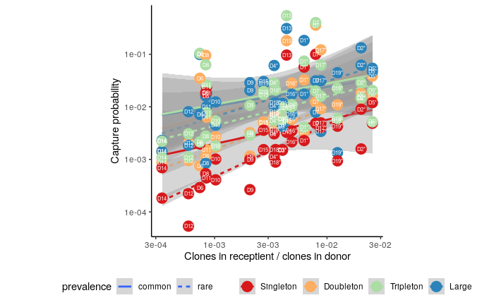

```r
data.s3  %>%
  ggplot(aes(x = clones.rec / clones.don, y = alpha / (alpha + beta),
             group = paste(donor.quantile, prevalence),
             linetype =  prevalence,
             color = factor( donor.quantile, levels = c("Singleton",
                                                      "Doubleton",
                                                      "Tripleton",
                                                      "Large")))) +
  geom_smooth(method = "lm", aes(), size = 1) +
  geom_point(size = 5) +
  geom_text(aes(label = sample.id), size = 2, color = "white") +
  scale_x_log10("Clones in receptient / clones in donor") +
  scale_y_log10("Capture probability") +
  scale_color_brewer("", palette = "Spectral") +
  theme_classic() +
  theme(aspect = 1, legend.position = "bottom")
```

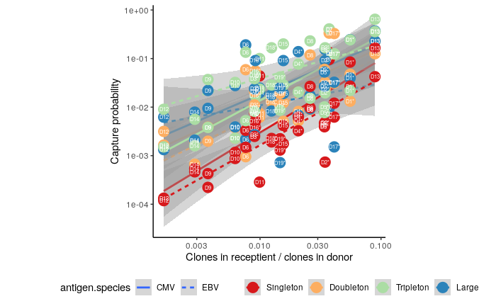

```r
data.s2 <- data %>% filter((antigen.species == 'EBV')|(antigen.species == 'CMV'))%>%
  filter(donor.quantile != "Missing") %>%
  group_by(sample.id) %>%
  mutate(total.don = sum(cloneCount.don, na.rm = T),
         clones.don = length(unique(aaSeqCDR3.don)), # note here we count +1 for NA, maybe should modify it
         total.rec = sum(cloneCount.rec, na.rm = T),
         clones.rec = length(unique(aaSeqCDR3.rec))) %>%
  group_by(sample.id, donor.quantile) %>%
  mutate(clones.don.quant = length(unique(aaSeqCDR3.don))) %>%
  group_by(dli, sample.id, donor.quantile, total.don, clones.don, total.rec, clones.rec, clones.don.quant, antigen.species) %>%
  summarize(alpha = sum(!is.na(cloneCount.rec)) + alpha.prior,
            beta = sum(is.na(cloneCount.rec)) + beta.prior) %>%
  ungroup
data.s2  %>%
  ggplot(aes(x = clones.rec / clones.don, y = alpha / (alpha + beta),
             group = paste(donor.quantile, antigen.species),
             linetype =  antigen.species,
             color = factor( donor.quantile, levels = c("Singleton",
                                                      "Doubleton",
                                                      "Tripleton",
                                                      "Large")))) +
  geom_smooth(method = "lm", aes(), size = 1) +
  geom_point(size = 5) +
  geom_text(aes(label = sample.id), size = 2, color = "white") +
  scale_x_log10("Clones in receptient / clones in donor") +
  scale_y_log10("Capture probability") +
  scale_color_brewer("", palette = "Spectral") +
  theme_classic() +
  theme(aspect = 1, legend.position = "bottom")
```

```r
data.coord <- data.s2 %>%
  group_by(donor.quantile) %>%
  mutate(logRecaptureProb = log(alpha / (alpha + beta)),
         logClonesRecepient = log(clones.rec),
         logClonesDonor = log(clones.don)) %>%
  ungroup %>%
  mutate(donor.quantile = factor(donor.quantile, levels = c("Singleton",
                                                       "Doubleton",
                                                       "Tripleton",
                                                       "Large")))

data.coord %>%
  ungroup %>% mutate(donor.quantile = as.factor(donor.quantile)) %>%
  do(lm(.$logRecaptureProb ~ .$dli + .$logClonesRecepient + .$logClonesDonor + .$antigen.species + .$donor.quantile) %>% tidy)
```

| term | estimate | std.error | statistic | p.value |
| --- | --- | --- | --- | --- |
| (Intercept) | 0.8579279 | 1.5425309 | 0.556182 | 5.789497e-01 |
| .$dliTRUE | -0.6786324 | 0.3400330 | -1.995784 | 4.784357e-02 |
| .$logClonesRecepient | 1.1865286 | 0.1033012 | 11.486102 | 4.401075e-22 |
| .$logClonesDonor | -1.3336831 | 0.2306183 | -5.783075 | 4.386105e-08 |
| .$antigen.speciesEBV | -0.2698817 | 0.1974977 | -1.366506 | 1.739102e-01 |
| .$donor.quantileDoubleton | 1.3403396 | 0.2793039 | 4.798858 | 3.948071e-06 |
| .$donor.quantileTripleton | 2.1926866 | 0.2793039 | 7.850541 | 8.643239e-13 |
| .$donor.quantileLarge | 1.6044933 | 0.2793039 | 5.744615 | 5.278489e-08 |

[output not shown]